2023-01-16

## INTRODUCTION

In order to conduct this premise, it had been used the the open data offer by ‘Visit Scotland’ that can be consult in the website of the Scottish Government : ‘statistics.gov.scot’

## Data Context/ Disclaimer/ Assumptions

Before start, it has to be some considerations.

- Some of the data used presented the variable ‘region of residence’, and observations are ‘All GB’, ‘England’ and ‘Scotland’. Due the fact that GB means England, Scotland and Wales,it has been used the the ‘All GB’ observation because - in our opinion- its the most accurate.
- Also one visitor can realize more than one visits and could lead to a misunderstanding / misinterpretation in the total number of visitors.
- In 2019, Visit Scotland in conjunction with Visit England and Visit Wales change the parameters for recording domestic overnight trips and domestic day trips. It is believed that this new method can produce differents interpretations in visits and expenditure. More info. ‘INSIGHT DEPARTMENT: GBTS 2021 Methodology and Quality’
- Therefore, the intention is to show a glimpse about how was the tourism in the country in 2019 and during previous years. All before the introduction of the new method and the disruption caused by the pandemic and the lockdown restrictions during 2020,2021 and the beginning of 2022 plus the current world economic recession.

## Definitions

Tourism day trip is defined as:

- Taking part in one of a pre-defined list of activities (based on international tourism definitions)
- Spending 3 or more hours out of the home on this activity
- The activity is not doing “very regularly” by the respondent
- The activity not being carried out in the place that the respondent lives or works
- The exception to this was trips to visitor attractions, live sporting events and special public events, which are all counted as tourism day trips even when in the place of residence, provided they fulfill the other three criteria.

## Tourism in Scotland

The first question should it should be ask is ‘how much money means the domestic tourist activity for Scotland?’. This visualization answers the question for the period 2013 to 2019. The highest value was in 2017 which nearly 6 thousand millions pounds and the low 2015 with a bit less than 4 thousand millions pounds.

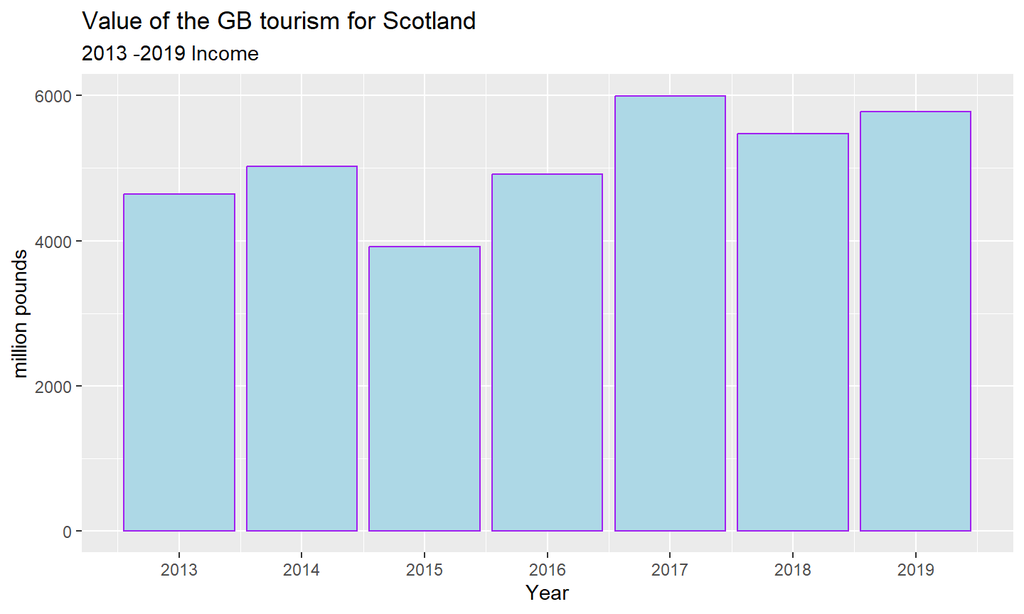

We can see which are the Tourism Activity and their income in the total value for the year 2019 “Went out for a meal” was the highest Income. One thing you can do once per week, not ‘very regularly’

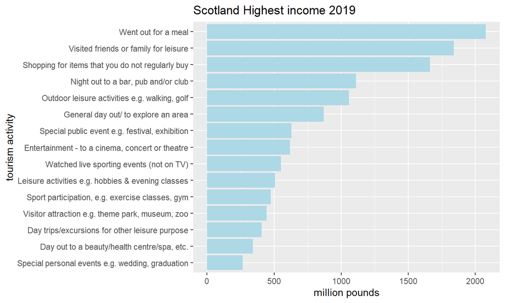

## However..

The higher number of higher visits for the same year was… visit friends or family for leisure (tourism activities?)

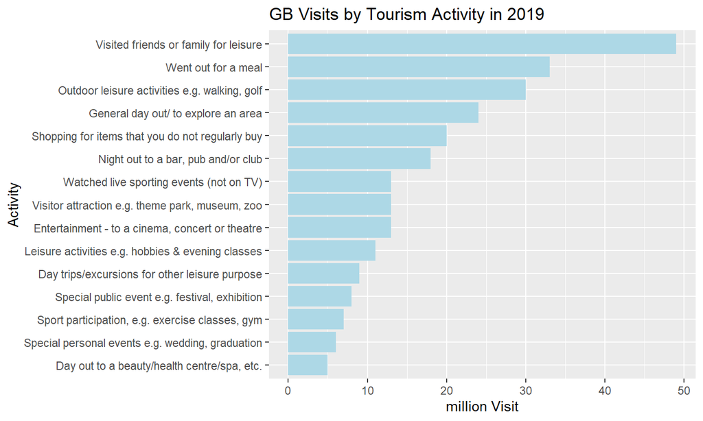

Where were the location of these visits?

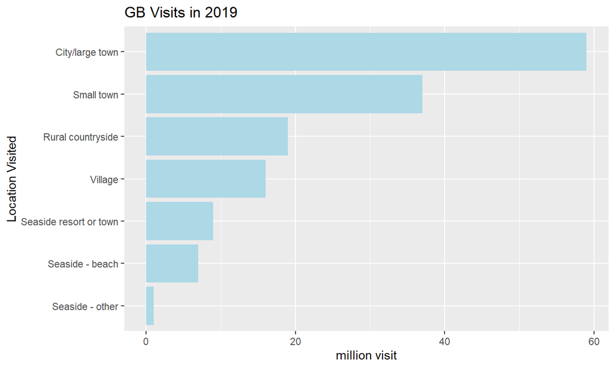

And the expenditure?

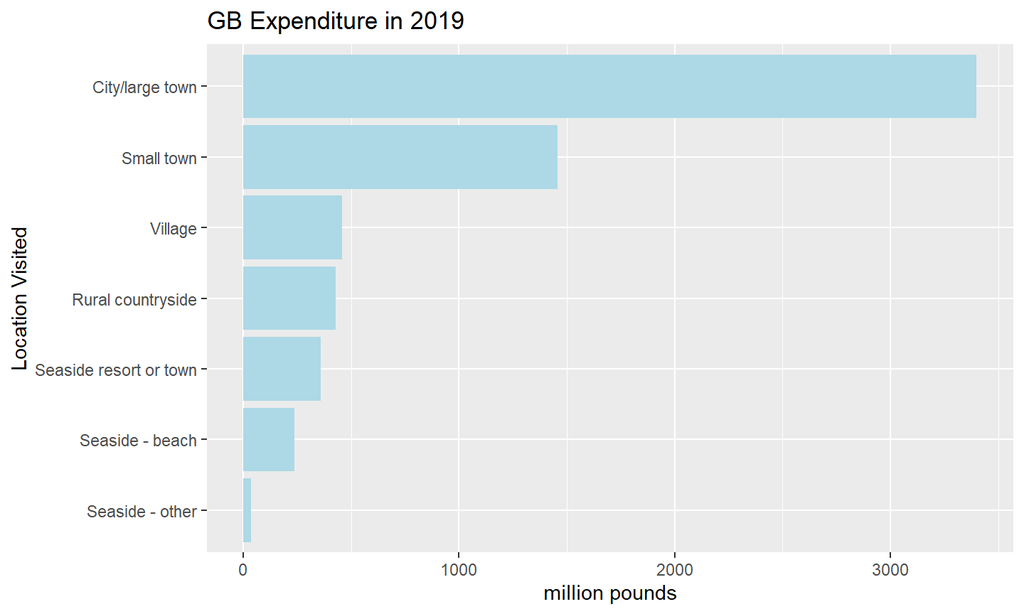

## But

Even if the large cities attract the majority of visits and expenditure, there is a - relative- decrease in comparison with other locations such as countryside or seaside.

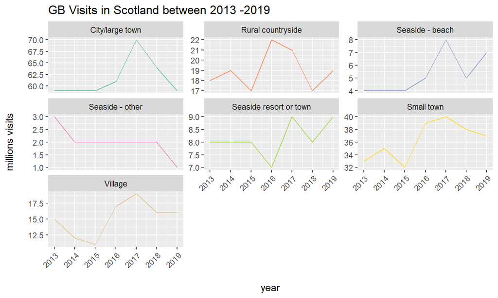

## Follow the money

This visualization shows the evolution for the period 2013 - 2019 the visits in city/ large town has fallen but the expenditure there has increase in the last year. the Rural countryside shows the opposite the expenditure has decrease but the visits has increase from 2018. It can be observed that for the year 2019 visits and expenditure are correlated except for the values Village/Rural countryside. In happens as well in the year 2018 and 2014.

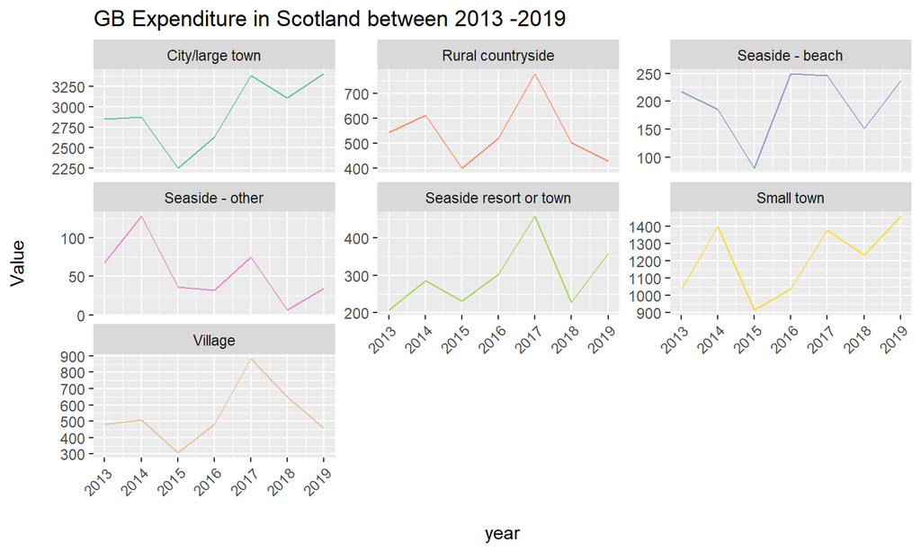

## General view.

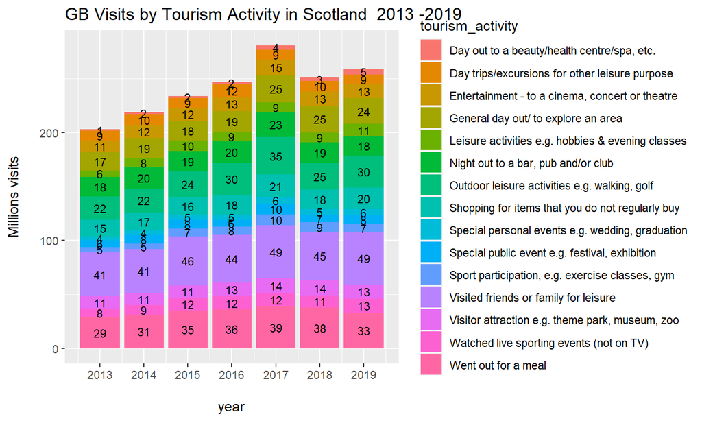

## Understanding the visitors from 2013 till 2019

This is the general evolution of visiting Scotland by age. It can argue that there is not a clear tendency, each group of age had a preferred year in visit Scotland

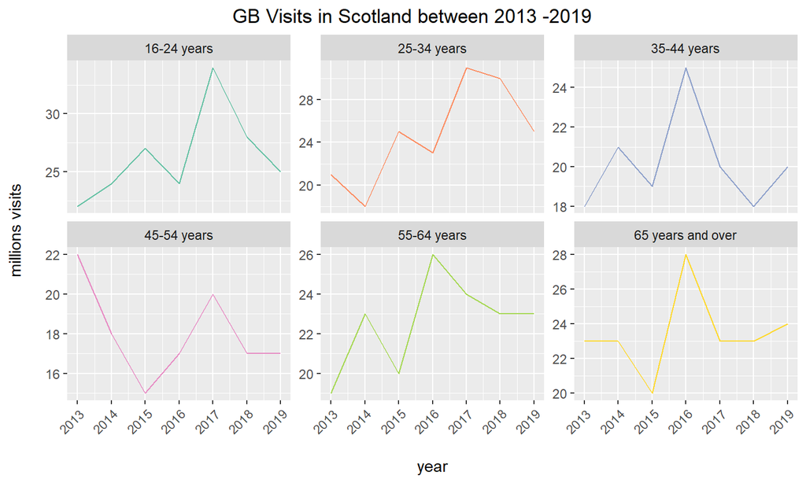

## For the year 2019

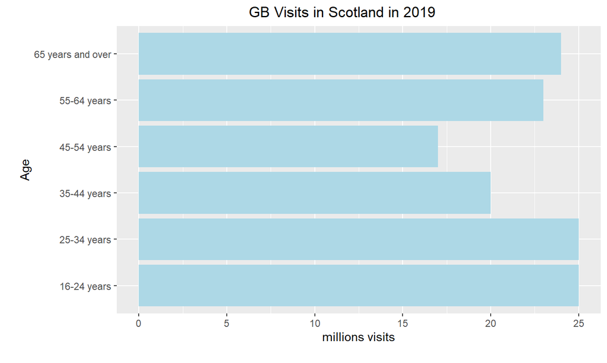

## Expenditure

Millions Expenditure by visitors age. More spend people between 25-34 , 55-56 and 35-44.

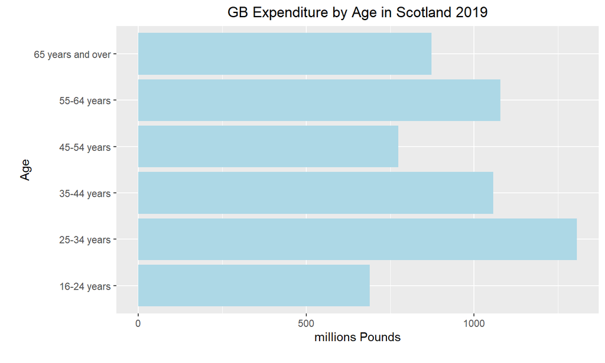

## How moved the money in 2019?

More Female than Male

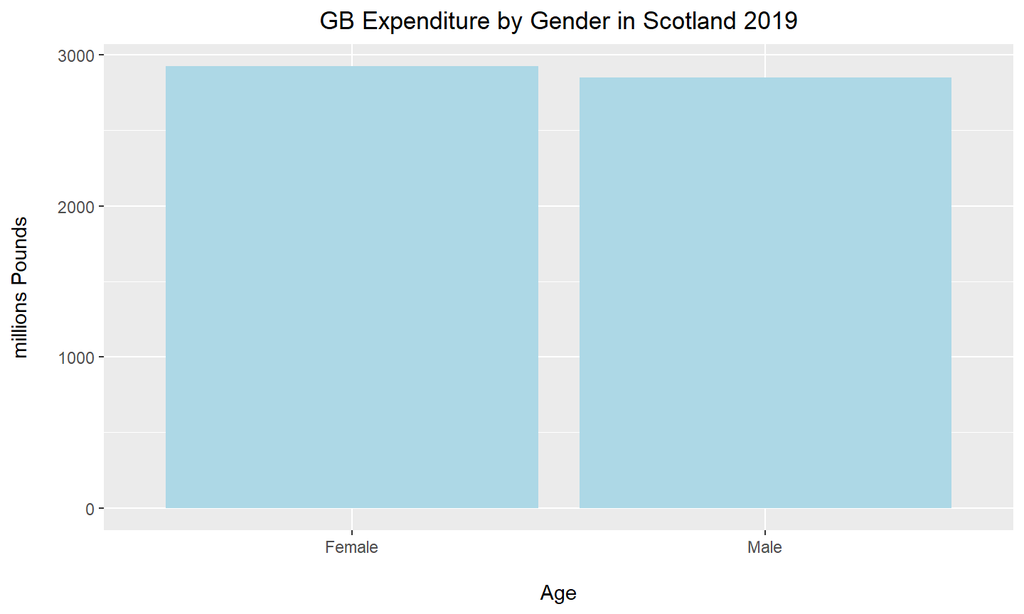

## And previous years

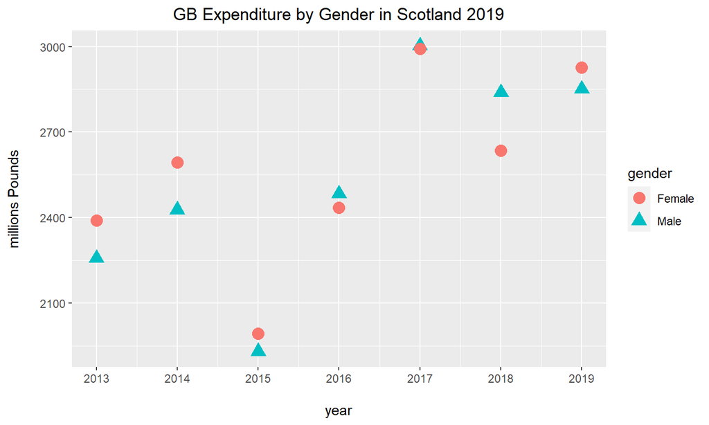

## Marital Status in 2019

The level of expenditure is higher in married than not married. (Could be an ethical consideration - why/ How the spend the money-)

[figure not shown]

## Marital Status since 2013

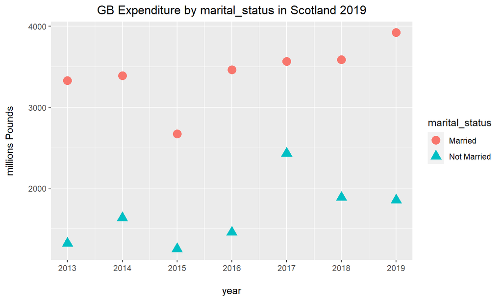

## Childrens? 2019

No, thanks.

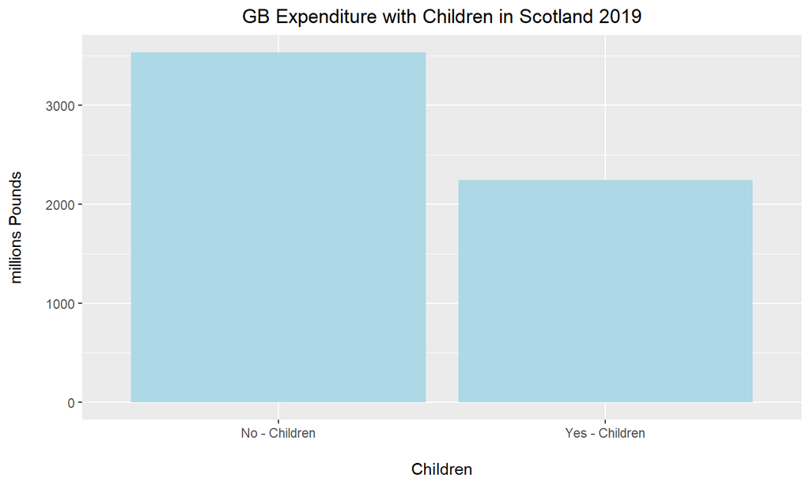

## Childrens during period 2013-2019

No, thanks. Looks like a general tendency that couples with kids try not to spend much money or go for free stuff.

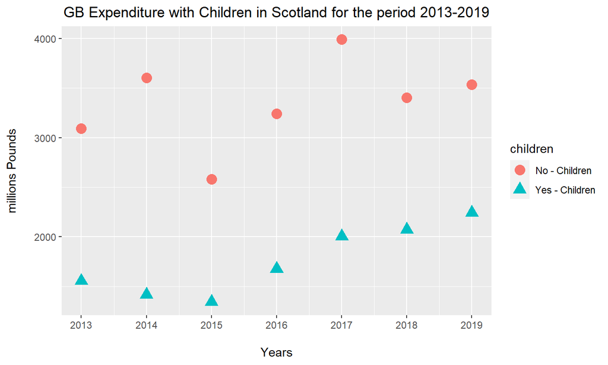

## Millions Expenditure by Employment Status.

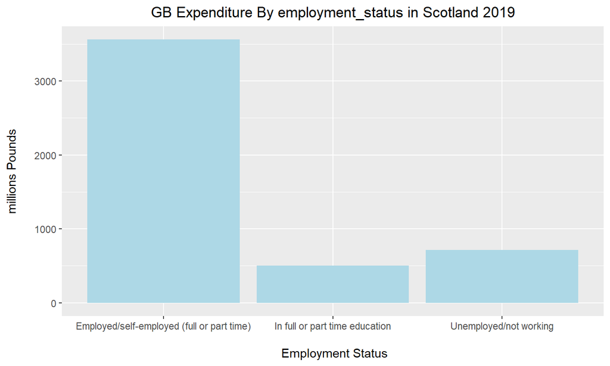

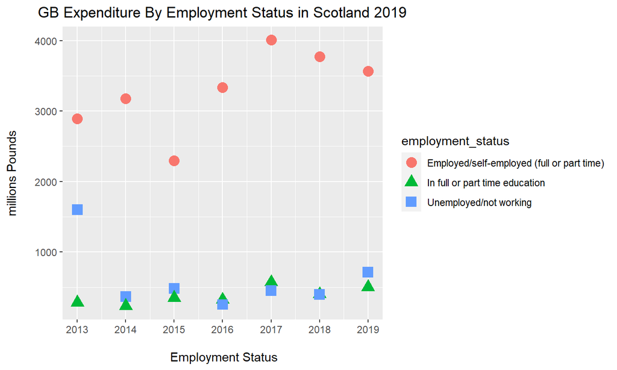

## SocialGrade

Is important the social grade? Is ethical? Funny the most expenditure is the highest grade occupation but the second is in theory the lowest grade occupation ( less money/ less cultured person? assumption, another ethical consideration)

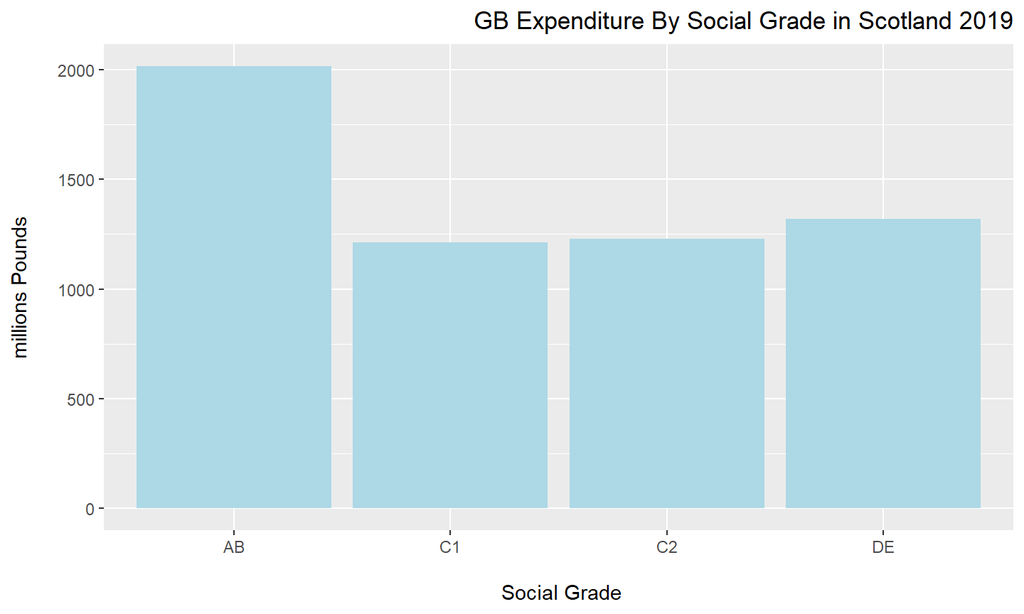

## For the period 2013 - 2019

The obvious for social grade but not the last year. Is it ethical? ‘help’ people to spend money

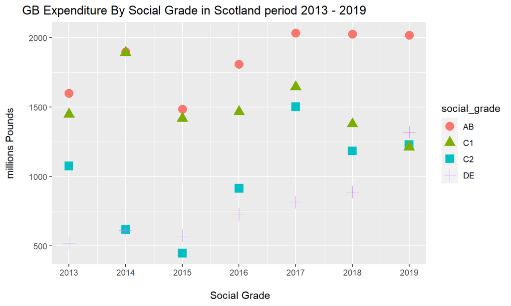

##In conclusion

The data point out that the profile person that spend more money is a young / middle- age female married - maybe recently- without children with employ and high social grade

## Transport means where to go, free to travel….

How travel people and their expenditure in relation.

## Visits in 2019

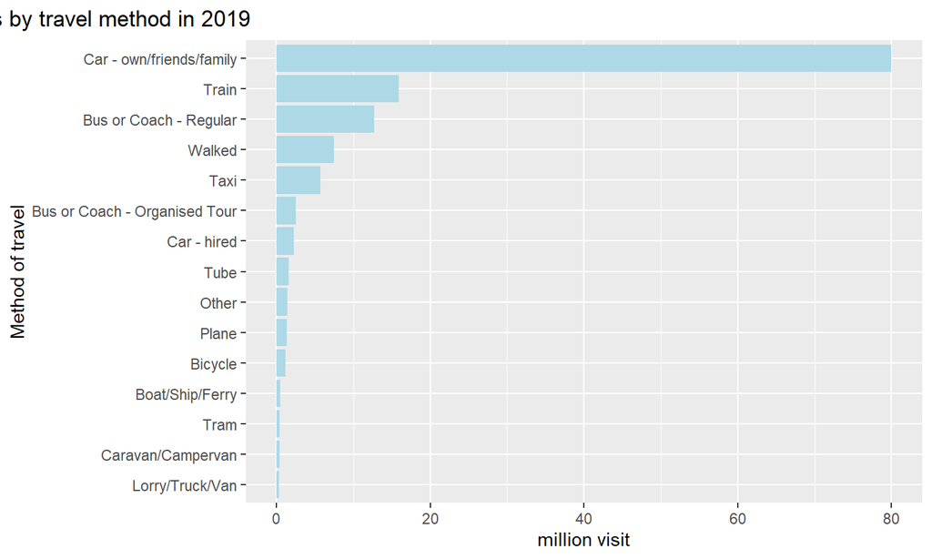

## Expenditure in 2019

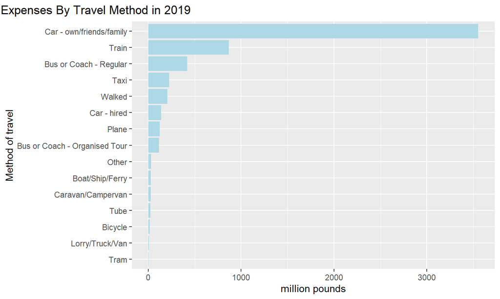

- The most used transport is the car
- Only 0.4 take a caravan or campervan but the value of their spend is 24.2 millions of pounds.
- There are few things interesting, 0.5 million visits arrive by sea (boat/ship/ ferry). Where is cruise is boat a cruise? Ship and ferry can include go to the Islands?
- We can conclude that is minimum visits some Islands that is needed a sea transport such as Mull, Islay, Arran. Others places such as western Islands , Orkney or Shetlands have airports. Visit the Islands imply more nights and more expenses
- In 2019 , airplane transport was around 1.5 million of visits (10th position) but reported 123 millions of pounds ( 7 th position). Planes are more to arrive to any airport and later take a hired vehicle , taxi…. So its a way to arrive to Scotland more than travel around the country.

## Where they paying out

The data confirms that they are the large cities (Edinburgh and Glasgow) and the Highlands the places the centers of the expenditure. Places in relation with the use of car and train as a main transport.

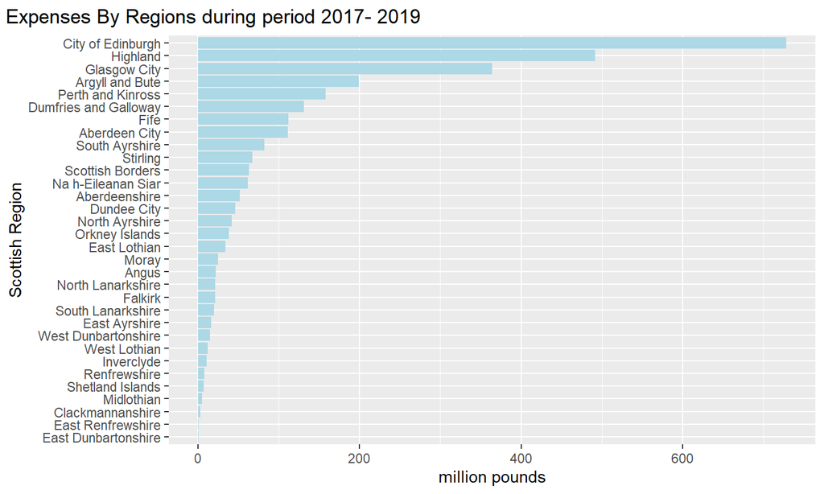

## Go to…

For the plot, it could be deduced that is not only how to arrive,it is the offer of activities. An example could be the fact that The Western Islands ( Na h-Elleanan Siar) is over regions of the ‘Central bell’.

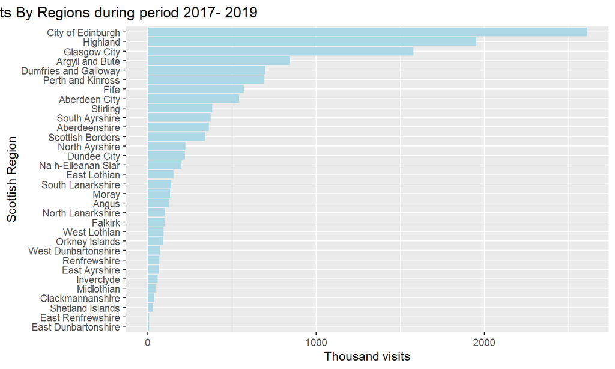